# Support Vector Machine

Jingyu Bao

2016-11-14

## R Notebook YAML code

[here](https://github.com/rstudio/rmarkdown/tree/gh-pages) and [here](http://rmarkdown.rstudio.com/html_document_format.html)

## Simple Usage

We use the segmentationData in **caret** package. The Class is the predict variable (y label).

```r
data(segmentationData)
segmentationData %>%
    head(10)
```

|  | Cell | Case | Class | AngleCh1 | AreaCh1 | AvgIntenCh1 | AvgIntenCh2 | AvgIntenCh3 | AvgIntenCh4 | ConvexHullAreaRatioCh1 | ConvexHullPerimRatioCh1 | DiffIntenDensityCh1 | DiffIntenDensityCh3 | DiffIntenDensityCh4 | EntropyIntenCh1 | EntropyIntenCh3 | EntropyIntenCh4 | EqCircDiamCh1 | EqEllipseLWRCh1 | EqEllipseOblateVolCh1 | EqEllipseProlateVolCh1 | EqSphereAreaCh1 | EqSphereVolCh1 | FiberAlign2Ch3 | FiberAlign2Ch4 | FiberLengthCh1 | FiberWidthCh1 | IntenCoocASMCh3 | IntenCoocASMCh4 | … |
| --- | --- | --- | --- | --- | --- | --- | --- | --- | --- | --- | --- | --- | --- | --- | --- | --- | --- | --- | --- | --- | --- | --- | --- | --- | --- | --- | --- | --- | --- | --- |
| 1 | 207827637 | Test | PS | 143.247705 | 185 | 15.71186 | 4.954802 | 9.548023 | 2.214689 | 1.124509 | 0.9196827 | 29.51923 | 13.77564 | 6.826923 | 4.969781 | 4.371017 | 2.718884 | 15.36954 | 3.060676 | 336.9691 | 110.0963 | 742.1156 | 1900.996 | 1.000000 | 1.000000 | 26.98132 | 7.410365 | 0.011183899 | 0.050448005 | … |
| 2 | 207932307 | Train | PS | 133.752037 | 819 | 31.92327 | 206.878517 | 69.916880 | 164.153453 | 1.263158 | 0.7970801 | 31.87500 | 43.12228 | 79.308424 | 6.087592 | 6.642761 | 7.880155 | 32.30558 | 1.558394 | 2232.9055 | 1432.8246 | 3278.7256 | 17653.525 | 1.487935 | 1.352374 | 64.28230 | 13.167079 | 0.028051061 | 0.012594975 | … |
| 3 | 207932463 | Train | WS | 106.646387 | 431 | 28.03883 | 116.315534 | 63.941748 | 106.696602 | 1.053310 | 0.9354750 | 32.48771 | 35.98577 | 51.357050 | 5.883557 | 6.683000 | 7.144601 | 23.44892 | 1.375386 | 802.1945 | 583.2504 | 1727.4104 | 6750.985 | 1.300522 | 1.522316 | 21.14115 | 21.141150 | 0.006862315 | 0.006141691 | … |
| 4 | 207932470 | Train | PS | 69.150325 | 298 | 19.45614 | 102.294737 | 28.217544 | 31.028070 | 1.202625 | 0.8658291 | 26.73228 | 22.91732 | 26.393701 | 5.420065 | 5.436732 | 5.778329 | 19.50279 | 3.391220 | 724.7143 | 213.7031 | 1194.9320 | 3884.084 | 1.220424 | 1.733250 | 43.14112 | 7.404412 | 0.030962071 | 0.011033195 | … |
| 5 | 207932455 | Test | PS | 2.887837 | 285 | 24.27574 | 112.415441 | 20.474265 | 40.577206 | 1.109333 | 0.9568124 | 31.58065 | 21.70968 | 25.032258 | 5.658248 | 5.285671 | 5.235857 | 19.05279 | 2.741380 | 607.5185 | 221.6105 | 1140.4263 | 3621.385 | 1.491387 | 1.384547 | 34.74977 | 8.483574 | 0.022768411 | 0.079690842 | … |
| 6 | 207827656 | Test | WS | 40.748298 | 172 | 325.93333 | 653.606061 | 128.690909 | 346.854545 | 1.005831 | 0.9926363 | 92.56291 | 61.92715 | 145.708609 | 6.998111 | 6.805538 | 7.119323 | 14.83940 | 1.039726 | 176.7693 | 170.0153 | 691.8027 | 1710.989 | 1.309504 | 1.362191 | 12.38420 | 12.384199 | 0.008914083 | 0.009155300 | … |
| 7 | 207827659 | Test | WS | 173.957833 | 177 | 260.05917 | 596.420118 | 123.840237 | 273.295858 | 1.014164 | 0.9840211 | 89.22654 | 47.81553 | 139.291262 | 6.896239 | 6.660887 | 7.032449 | 15.01819 | 1.088583 | 187.4918 | 172.2348 | 708.5737 | 1773.582 | 1.244973 | 1.545225 | 12.59624 | 12.596237 | 0.008166438 | 0.008311984 | … |
| 8 | 207827661 | Test | PS | 179.800467 | 251 | 18.33750 | 5.729167 | 17.233333 | 1.554167 | 1.200389 | 0.8310554 | 28.61792 | 19.22170 | 5.382075 | 5.318070 | 5.085643 | 2.295804 | 17.89698 | 2.866415 | 514.8823 | 179.6259 | 1006.2585 | 3001.499 | 1.000000 | 1.000000 | 37.84863 | 7.117398 | 0.006116300 | 0.127326686 | … |
| 9 | 207932479 | Test | WS | 18.936420 | 495 | 16.05285 | 89.482030 | 13.716702 | 51.427061 | 1.192308 | 0.8219601 | 26.98404 | 15.06613 | 36.117446 | 5.189203 | 4.493851 | 6.281189 | 25.12493 | 1.506684 | 1032.8193 | 685.4917 | 1983.1678 | 8304.491 | 1.355246 | 1.456272 | 44.14773 | 11.728889 | 0.089600535 | 0.019221940 | … |
| 10 | 207932480 | Test | WS | 153.252427 | 384 | 17.74387 | 89.931880 | 20.444142 | 63.111717 | 1.160365 | 0.8649792 | 25.76036 | 18.23077 | 38.059172 | 5.334973 | 5.320425 | 6.740386 | 22.13132 | 1.755000 | 761.8320 | 434.0923 | 1538.7370 | 5675.713 | 1.762420 | 1.659566 | 37.24447 | 10.792994 | 0.012277917 | 0.008028741 | … |

```r
set.seed(100)
trainIndex <- createDataPartition(segmentationData$Class, p = .8,
                                  list = FALSE,
                                  times = 1)
segTrain <- segmentationData[trainIndex,]
segTest <- segmentationData[-trainIndex,]
trainX <- segTrain[,4:61]
set.seed(1000)
fitControl <- trainControl(## 10-fold CV
                           method = "repeatedcv",
                           number = 10,
                           ## repeated five times
                           repeats = 5)
svmFit <- train(x = trainX,
                y = segTrain$Class,
                data = segTrain,
                method = "svmLinear",
                trControl = fitControl)
svmFit
```

```
Support Vector Machines with Linear Kernel

1616 samples
  58 predictor
   2 classes: 'PS', 'WS'

No pre-processing
Resampling: Cross-Validated (10 fold, repeated 5 times)
Summary of sample sizes: 1455, 1454, 1455, 1454, 1454, 1454, ...
Resampling results:

  Accuracy   Kappa
  0.8039867  0.5683145

Tuning parameter 'C' was held constant at a value of 1
```

```r
svmFit$finalModel
```

```
Support Vector Machine object of class "ksvm"

SV type: C-svc  (classification)
 parameter : cost C = 1

Linear (vanilla) kernel function.

Number of Support Vectors : 698

Objective Function Value : -665.4249
Training error : 0.17203
```

C is the penalty parameter of the error term. In this linear kernel function case, C remains $1$.

Predict/Test

```r
segPred <- predict(svmFit, segTest[,4:61])
segPred %>%
    head(10)
```

```
 [1] WS PS WS PS PS WS PS PS PS PS
Levels: PS WS
```

```r
confusionMatrix(data = segPred, reference = segTest$Class)
```

```
$positive
[1] "PS"

$table
          Reference
Prediction  PS  WS
        PS 217  34
        WS  43 109

$overall
      Accuracy          Kappa  AccuracyLower  AccuracyUpper   AccuracyNull
  8.089330e-01   5.885192e-01   7.670911e-01   8.461675e-01   6.451613e-01
AccuracyPValue  McnemarPValue
  4.127379e-13   3.619348e-01

$byClass
         Sensitivity          Specificity       Pos Pred Value
           0.8346154            0.7622378            0.8645418
      Neg Pred Value            Precision               Recall
           0.7171053            0.8645418            0.8346154
                  F1           Prevalence       Detection Rate
           0.8493151            0.6451613            0.5384615
Detection Prevalence    Balanced Accuracy
           0.6228288            0.7984266

$mode
[1] "sens_spec"

$dots
list()

attr(,"class")
[1] "confusionMatrix"
```

```r
postResample(pred = segPred, obs = segTest$Class)
```

```
 Accuracy     Kappa
0.8089330 0.5885192
```

For Kappa statistic, from [here](http://stats.stackexchange.com/questions/82162/kappa-statistic-in-plain-english)

> Kappa = (observed accuracy - expected accuracy)/(1 - expected accuracy)

> There is not a standardized interpretation of the kappa statistic. According to Wikipedia (citing their paper), Landis and Koch considers 0-0.20 as slight, 0.21-0.40 as fair, 0.41-0.60 as moderate, 0.61-0.80 as substantial, and 0.81-1 as almost perfect. Fleiss considers kappas > 0.75 as excellent, 0.40-0.75 as fair to good, and < 0.40 as poor.

## Next Step (Theory)

The RBF kernel
$$K(x,y) = \exp \Big(\frac{||x-y||^2}{\gamma}\Big) = \exp(||x||^2/\gamma)\exp(||y||^2/\gamma) \sum_{j = 0}^{\infty} \frac{(-2x\cdot y)^j}{\gamma^j j!}$$
is a similarity measure which project the variables into infinity space $\mathbb{R}^{\infty}$.

from here

> In general, the RBF kernel is a reasonable first choice. This kernel nonlinearly maps samples into a higher dimensional space so it, unlike the linear kernel, can handle the case when the relation between class labels and attributes is nonlinear. Furthermore, the linear kernel is a special case of RBF

> If the number of features is large, one may not need to map data to a higher dimensional space. That is, the nonlinear mapping does not improve the performance. Using the linear kernel is good enough, and one only searches for the parameter C.

## Visualization

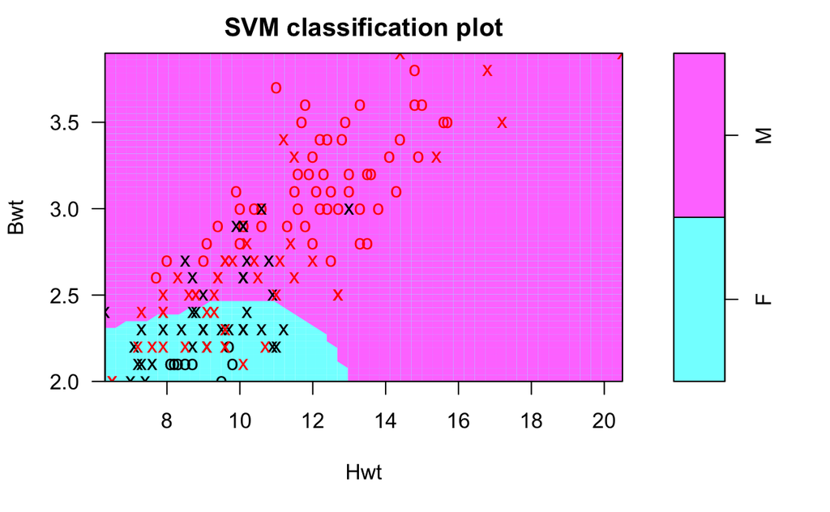

```r
library(e1071)
data(cats, package = "MASS")
m <- svm(Sex~., data = cats)
plot(m, cats)
```

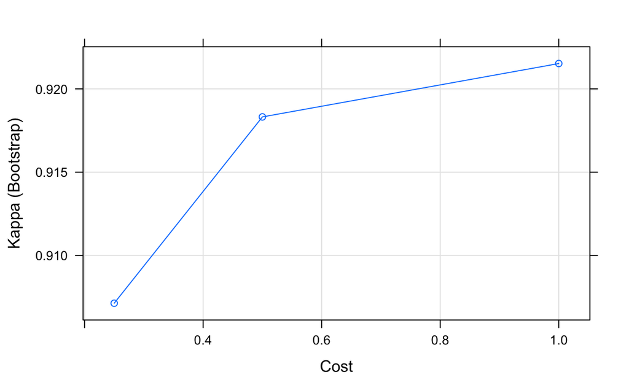

```r
svmRadialFit <- train(Species ~ .,
                data = iris,
                method = "svmRadial",
                metric = "Kappa",
                control = trainControl(method = "cv"))
plot(svmRadialFit, metric = svmRadialFit$metric)
```

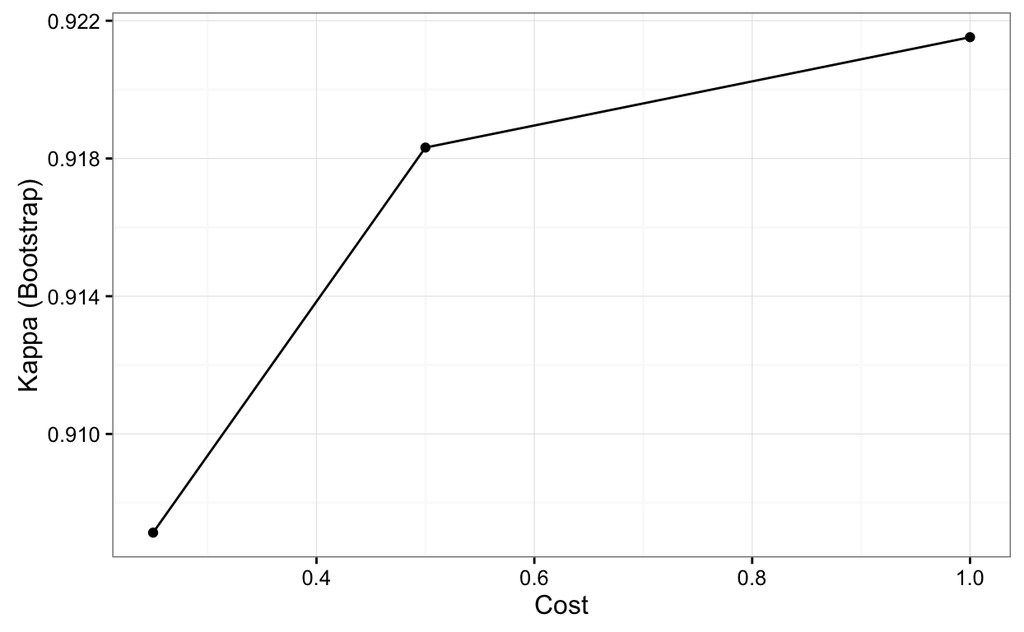

```r
ggplot(svmRadialFit) + theme_bw()
```

### Others

example from [here](https://www.r-bloggers.com/the-5th-tribe-support-vector-machines-and-caret/)

```r
## SUPPORT VECTOR MACHINE MODEL
# First pass
set.seed(1492)
# Setup for cross validation
ctrl <- trainControl(method="repeatedcv",   # 10fold cross validation
                     repeats=2,         # do 2 repititions of cv
                     summaryFunction=twoClassSummary,   # Use AUC to pick the best model
                     classProbs=TRUE)


#Train and Tune the SVM
svm.tune <- train(x =trainX,
                  y = segTrain$Class,
                  method = "svmRadial",   # Radial kernel
                  tuneLength = 9,                   # 9 values of the cost function
                  preProc = c("center","scale"),  # Center and scale data
                  metric = "ROC",
                  trControl = ctrl)
svm.tune
```

```
Support Vector Machines with Radial Basis Function Kernel

1616 samples
  58 predictor
   2 classes: 'PS', 'WS'

Pre-processing: centered (58), scaled (58)
Resampling: Cross-Validated (10 fold, repeated 2 times)
Summary of sample sizes: 1454, 1455, 1454, 1455, 1455, 1455, ...
Resampling results across tuning parameters:

  C      ROC        Sens       Spec
   0.25  0.8850716  0.8658654  0.7118421
   0.50  0.8899121  0.8798077  0.7135814
   1.00  0.8931251  0.8860577  0.7274955
   2.00  0.8937596  0.8927885  0.7301270
   4.00  0.8875554  0.8937500  0.7240321
   8.00  0.8748085  0.8831731  0.6909558
  16.00  0.8643200  0.8764423  0.6613733
  32.00  0.8558563  0.8754808  0.6423321
  64.00  0.8471522  0.8653846  0.6319117

Tuning parameter 'sigma' was held constant at a value of 0.01471974
ROC was used to select the optimal model using  the largest value.
The final values used for the model were sigma = 0.01471974 and C = 2.
```

Another example from [here](http://machinelearningmastery.com/non-linear-regression-in-r/)

```r
# load the package
library(kernlab)
# load data
data(longley)
# fit model
fit <- ksvm(Employed~., longley)
# summarize the fit
summary(fit)
```

```
Length  Class   Mode
     1   ksvm     S4
```

```r
# make predictions
predictions <- predict(fit, longley)
# summarize accuracy
rmse <- mean((longley$Employed - predictions)^2)
print(rmse)
```

```
[1] 0.1495343
```